# Data Analysis Project - Proposal

Hitesh Yadav (hitesh2)

Byunggeun Park (bpark14)

Avinika Pandugayala (avinika2)

July 21, 2023

## Introduction

### Overview

The housing market in today’s day and age is influenced by a variety of factors like location, size of the house, amenities, school district and above all the economic conditions. The project is to predict the price of a house based on some of these factors. We aim to create a model using techniques in R and create a predictive model that can be used to estimate the price.

The data we are going to use is obtained from Kaggle and can be found at the link [here](https://www.kaggle.com/competitions/house-prices-advanced-regression-techniques/data) (Anna Montoya 2016). We are not considering the economic conditions in this project as one of the factors for the price of the house and keeping it as out of scope for this analysis project.

### Tentative Title

As we plan to explore the data and build a predictive model for the pricing of the house we may have different predictor variables that can influence the path we take for the project. Below are some of the titles that the project can have based on our model we create:

- **Modeling the Dynamics of House Prices**
- **Understanding the Factors That Drive House Prices**
- **Housing Market Analytics: Predicting Property Sale Prices**
- **Predicting House Prices: A Regression Analysis**
- **Predicting Real Estate Prices: A Comprehensive Regression Study**

## Dataset

The data set we are using is sourced from a Kaggle competition in the link [here](https://www.kaggle.com/competitions/house-prices-advanced-regression-techniques/data) (Anna Montoya 2016).

From the competition Acknowledgements

*The Ames Housing dataset was compiled by Dean De Cock for use in data science education. It’s an incredible alternative for data scientists looking for a modernized and expanded version of the often cited Boston Housing dataset.*

### Data files

The dataset is divided into 2 files that include training and test data. The dataset also includes a file that has description of the fields of the dataset.

```r
library(readr)
require(plyr)
require(stringr)
housing_train = read.csv("data/train.csv")
housing_test = read.csv("data/test.csv")
data_desc = read.csv("data/field_descriptions.csv")
```

- `train.csv` - Training dataset that contains `1460` observations and `81` variables.
- `test.csv` - Test dataset that contains `1459` observations and `80` variables.
- `data_description.csv` - Metadata for variables in the file. Originally prepared by Dean De Cock. (Anna Montoya 2016)
- `sample_submission.csv` - The file contains the sale price for the test data.

For our final project we will combine the training and test data to do a 80-20 split. We will use the sale price values from `sample_submission.csv` to add the missing `SalePrice` variable in the test data.

### Variables/Data fields

| Variable | Type | Description |
| --- | --- | --- |
| Alley | character | Type of alley access |
| BldgType | character | Type of dwelling |
| BsmtCond | character | General condition of the basement |
| BsmtExposure | character | Walkout or garden level basement walls |
| BsmtFinSF1 | integer | Type 1 finished square feet |
| BsmtFinSF2 | integer | Type 2 finished square feet |
| BsmtFinType1 | character | Quality of basement finished area |
| BsmtFinType2 | character | Quality of second finished area (if present) |
| BsmtFullBath | integer | Basement full bathrooms |
| BsmtHalfBath | integer | Basement half bathrooms |
| BsmtQual | character | Height of the basement |
| BsmtUnfSF | integer | Unfinished square feet of basement area |
| CentralAir | character | Central air conditioning |
| Condition1 | character | Proximity to main road or railroad |
| Condition2 | character | Proximity to main road or railroad (if a second is present) |
| Electrical | character | Electrical system |
| EnclosedPorch | integer | Enclosed porch area in square feet |
| ExterCond | character | Present condition of the material on the exterior |
| Exterior1st | character | Exterior covering on house |
| Exterior2nd | character | Exterior covering on house (if more than one material) |
| ExterQual | character | Exterior material quality |
| Fence | character | Fence quality |
| FireplaceQu | character | Fireplace quality |
| Fireplaces | integer | Number of fireplaces |
| Foundation | character | Type of foundation |
| FullBath | integer | Full bathrooms above grade |
| Functional | character | Home functionality rating |
| GarageArea | integer | Size of garage in square feet |
| GarageCars | integer | Size of garage in car capacity |
| GarageCond | character | Garage condition |
| GarageFinish | character | Interior finish of the garage |
| GarageQual | character | Garage quality |
| GarageType | character | Garage location |
| GarageYrBlt | integer | Year garage was built |
| GrLivArea | integer | Above grade (ground) living area square feet |
| HalfBath | integer | Half baths above grade |
| Heating | character | Type of heating |
| HeatingQC | character | Heating quality and condition |
| HouseStyle | character | Style of dwelling |
| KitchenQual | character | Kitchen quality |
| LandContour | character | Flatness of the property |
| LandSlope | character | Slope of property |
| LotArea | integer | Lot size in square feet |
| LotConfig | character | Lot configuration |
| LotFrontage | integer | Linear feet of street connected to property |
| LotShape | character | General shape of property |
| LowQualFinSF | integer | Low quality finished square feet (all floors) |
| MasVnrArea | integer | Masonry veneer area in square feet |
| MasVnrType | character | Masonry veneer type |
| MiscFeature | character | Miscellaneous feature not covered in other categories |
| MiscVal | integer | $Value of miscellaneous feature |
| MoSold | integer | Month Sold |
| MSSubClass | integer | The building class |
| MSZoning | character | The general zoning classification |
| Neighborhood | character | Physical locations within Ames city limits |
| OpenPorchSF | integer | Open porch area in square feet |
| OverallCond | integer | Overall condition rating |
| OverallQual | integer | Overall material and finish quality |
| PavedDrive | character | Paved driveway |
| PoolArea | integer | Pool area in square feet |
| PoolQC | character | Pool quality |
| RoofMatl | character | Roof material |
| RoofStyle | character | Type of roof |
| SaleCondition | character | Condition of sale |
| SalePrice | integer | The property’s sale price in dollars. This is the target variable that you’re trying to predict. |
| SaleType | character | Type of sale |
| ScreenPorch | integer | Screen porch area in square feet |
| Street | character | Type of road access |
| TotalBsmtSF | integer | Total square feet of basement area |
| TotRmsAbvGrd | integer | Total rooms above grade (does not include bathrooms) |
| Utilities | character | Type of utilities available |
| WoodDeckSF | integer | Wood deck area in square feet |
| YearBuilt | integer | Original construction date |
| YearRemodAdd | integer | Remodel date |
| YrSold | integer | Year Sold |

## Data Exploration

For any data analysis project its good to know the the underlying data and the values. Specially what are types of the data and fields we can use to do the prediction.

We will use `SalePrice` as our response for the model and any or all fields in the dataset that we see fit for the model building.

### Sample Data

Exploring the data we can look at some of the columns and values in the dataset.

```r
dplyr::sample_n(housing_train, 10) %>%
  dplyr::select(SalePrice
                , YearBuilt
                , LotArea
                , Neighborhood
                , Utilities
                , BldgType
                , Fireplaces
                , GarageType) %>%
  kable(booktabs = T, linesep = "") %>%
  kable_styling(latex_options = c("HOLD_position", "repeat_header")
                , position = "center"
                , bootstrap_options = c("striped", "hover", "condensed")
                , fixed_thead = T)
```

| SalePrice | YearBuilt | LotArea | Neighborhood | Utilities | BldgType | Fireplaces | GarageType |
| --- | --- | --- | --- | --- | --- | --- | --- |
| 359100 | 1934 | 12168 | Crawfor | AllPub | 1Fam | 2 | Basment |
| 264561 | 2006 | 3982 | Blmngtn | AllPub | TwnhsE | 1 | Attchd |
| 180500 | 1964 | 14112 | NAmes | AllPub | 1Fam | 1 | Attchd |
| 100000 | 1938 | 8877 | Edwards | AllPub | 1Fam | 1 | Detchd |
| 187500 | 1980 | 14115 | NWAmes | AllPub | 1Fam | 2 | Attchd |
| 124000 | 1963 | 9204 | NAmes | AllPub | 1Fam | 0 | Detchd |
| 224900 | 1998 | 12137 | CollgCr | AllPub | 1Fam | 0 | Attchd |
| 207500 | 1984 | 5062 | StoneBr | AllPub | TwnhsE | 1 | Attchd |
| 315750 | 1996 | 11787 | NoRidge | AllPub | 1Fam | 1 | Attchd |
| 153500 | 1948 | 8100 | OldTown | AllPub | 1Fam | 0 | Detchd |

### Missing Values

We will use `DataExplorer` package to look into the data and initial profiling of the data. The idea is to understand the data better and make sure that we have detailed column analysis before we start building the model.

```r
library(ggplot2)

gtheme = theme(plot.title = element_text(hjust = 0.5),
        axis.line = element_line(colour = "black"), panel.grid.major = element_blank(),
        panel.grid.minor = element_blank(), panel.border = element_blank(),
        panel.background = element_blank(), text = element_text(size=10))

library(DataExplorer)
t(introduce(housing_train)) %>%
  kable(booktabs = T, linesep = "") %>%
  kable_styling(latex_options = c("HOLD_position", "repeat_header")
                , position = "center"
                , bootstrap_options = c("striped", "hover", "condensed")
                , fixed_thead = T)
```

| rows | 1460 |
| --- | --- |
| columns | 81 |
| discrete_columns | 43 |
| continuous_columns | 38 |
| all_missing_columns | 0 |
| total_missing_values | 6965 |
| complete_rows | 0 |
| total_observations | 118260 |
| memory_usage | 755280 |

Looking at the initial table above we can see that there are substantial missing values in the observations specially there are `0` complete rows that means we cannot just remove the missing value lines, doing so will have 0 observations for training. We will circle back on fixing the missing values in some time.

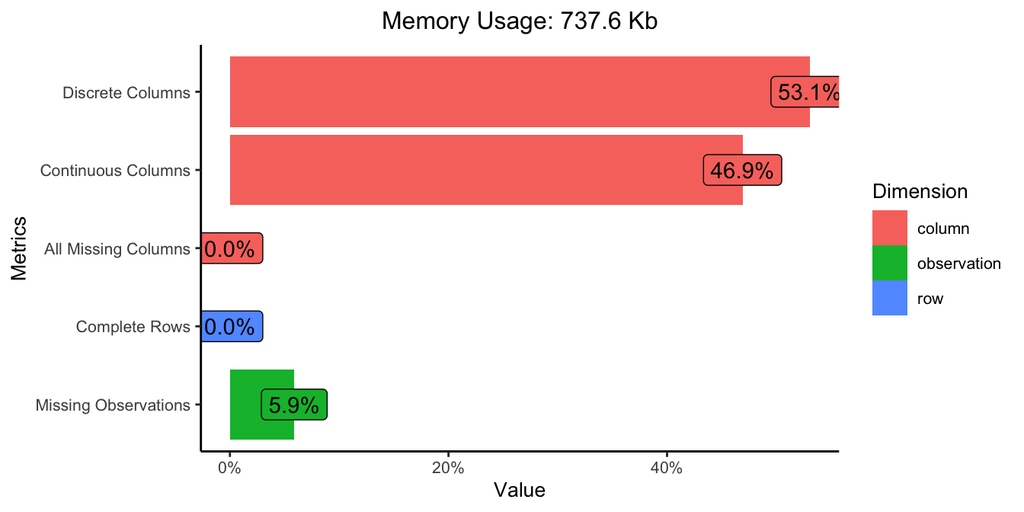

```r
plot_intro(housing_train, ggtheme = gtheme)
```

The intro plot also provides similar insights that we have`0%` complete and `5.9%` of the observations have missing values. We can further check the features that have missing values.

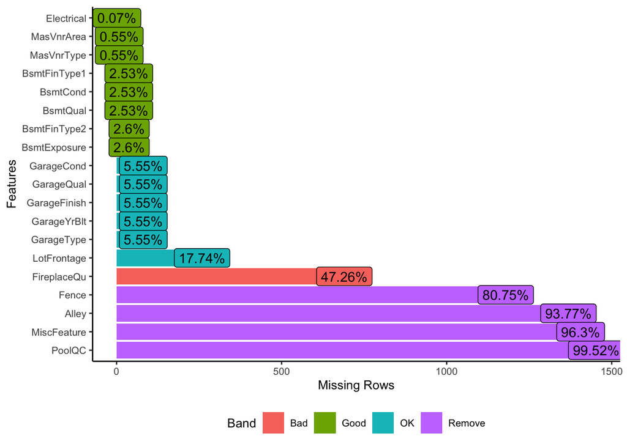

```r
plot_missing(housing_train, missing_only = TRUE, ggtheme = gtheme)
```

Above plot provides details on the columns have missing values. We can further dive into the missing values variables by creating a bar plot and checking if the missing values need to be updated.

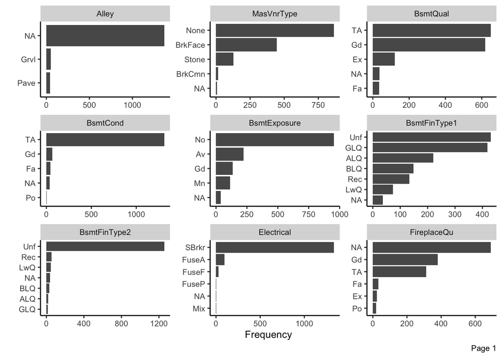

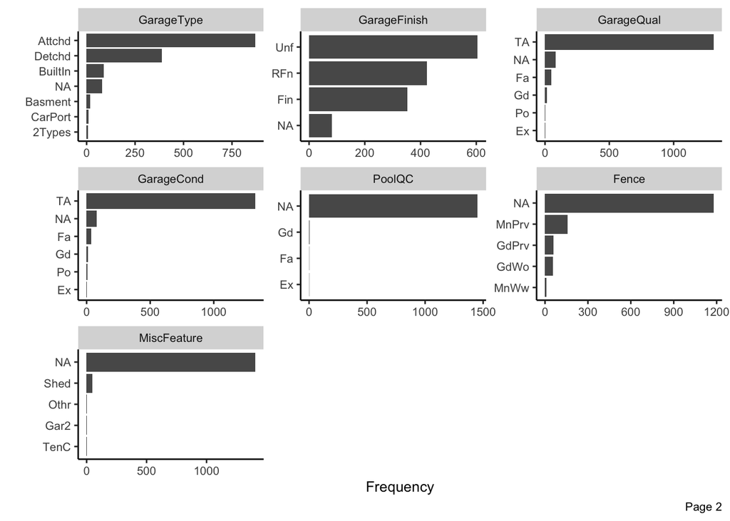

```r
missing_profile = profile_missing(housing_train)
missing_only = missing_profile[missing_profile$num_missing > 0,]
housing_missing_cols = housing_train[, names(housing_train) %in% missing_only$feature]

plot_bar(housing_missing_cols
         , ggtheme = gtheme)
```

```r
select_na_recs = rbind(dplyr::sample_n(housing_missing_cols[is.na(housing_missing_cols$LotFrontage),], 5)
                       , dplyr::sample_n(housing_missing_cols[is.na(housing_missing_cols$MasVnrArea),], 5)
                       , dplyr::sample_n(housing_missing_cols[is.na(housing_missing_cols$GarageYrBlt),], 5))

select_na_recs %>%
  dplyr::select(LotFrontage
                , GarageYrBlt
                , MasVnrArea) %>%
  mutate(LotFrontage = cell_spec(LotFrontage
                                 , color = "white"
                                 , background = ifelse(is.na(LotFrontage), "red", "green"))) %>%
  mutate(GarageYrBlt = cell_spec(GarageYrBlt
                                 , color = "white"
                                 , background = ifelse(is.na(GarageYrBlt), "red", "green"))) %>%
  mutate(MasVnrArea = cell_spec(MasVnrArea
                                , color = "white"
                                , background = ifelse(is.na(MasVnrArea), "red", "green"))) %>%
  kable(booktabs = T, linesep = "", escape=FALSE) %>%
  kable_styling(latex_options = c("HOLD_position", "repeat_header")
                , position = "center"
                , bootstrap_options = c("striped", "hover", "condensed")
                , fixed_thead = T)
```

| LotFrontage | GarageYrBlt | MasVnrArea |
| --- | --- | --- |
| NA | 1976 | 0 |
| NA | 1985 | 0 |
| NA | 1979 | 0 |
| NA | 1968 | 188 |
| NA | 1965 | 114 |
| 65 | 2007 | NA |
| NA | 1975 | NA |
| 35 | 2007 | NA |
| 75 | 2002 | NA |
| 67 | 2003 | NA |
| 60 | NA | 0 |
| 63 | NA | 120 |
| 60 | NA | 0 |
| 50 | NA | 0 |
| 50 | NA | 0 |

Looking at the bar plot for the Categorical variables we can see that there are a lot of records with `NA` as value. Even though the data descriptions says that the NA is not applicable this value might not work well with `R`.

Similarly we can see that the numerical fields `LotFrontage`, `GarageYrBlt` and `MasVnrArea` we have `NA` as value. In this case even though `NA` means not applicable for the data we would need to make sure that we handle these values correctly in programming.

### Data Cleaning

To handle this scenario we will update the values for character variables to `Other` and for numerical variables to `0` so that we can handle them better when building the model.

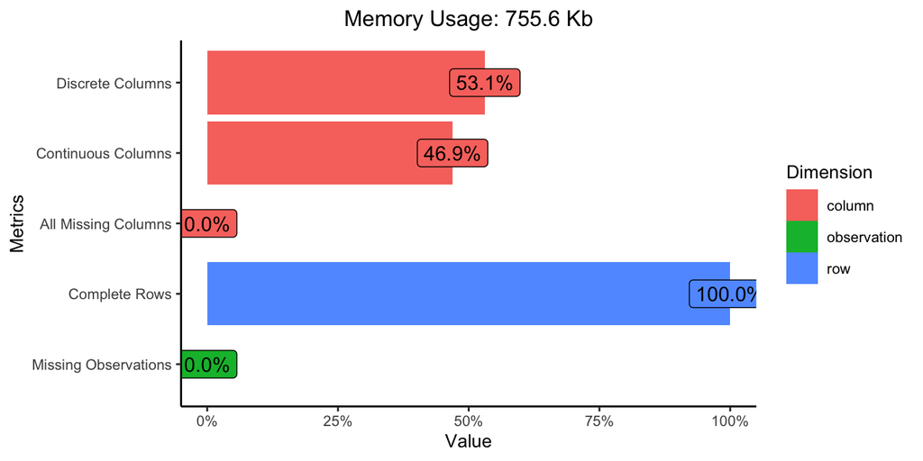

```r
# Fix the missing values
housing_train[c("LotFrontage"
                , "GarageYrBlt"
                , "MasVnrArea")][is.na(housing_train[c("LotFrontage"
                                                       , "GarageYrBlt"
                                                       , "MasVnrArea")])] = 0

housing_train[names(housing_missing_cols)][is.na(housing_train[names(housing_missing_cols)])] = "Other"

plot_intro(housing_train, ggtheme = gtheme)
```

```r
dplyr::sample_n(housing_train, 10) %>%
  dplyr::select(LotFrontage
                , GarageYrBlt
                , MasVnrArea) %>%
  kable(booktabs = T, linesep = "") %>%
  kable_styling(latex_options = c("HOLD_position", "repeat_header")
                , position = "center"
                , bootstrap_options = c("striped", "hover", "condensed")
                , fixed_thead = T)
```

| LotFrontage | GarageYrBlt | MasVnrArea |
| --- | --- | --- |
| 60 | 1962 | 0 |
| 98 | 2008 | 200 |
| 60 | 1950 | 0 |
| 100 | 2004 | 0 |
| 50 | 1937 | 0 |
| 60 | 1940 | 0 |
| 50 | 0 | 0 |
| 60 | 1915 | 0 |
| 56 | 2006 | 870 |
| 66 | 2006 | 1031 |

With the initial data cleaning done we can see from above plot that the data seems to be clean and usable now as we have removed all the `NA` and all rows are complete with values that we can use in `R` for modeling.

## Statement of Research and Interest

We as a team want to implement the techniques of statistical analysis we learned in this course and implement them in the housing data. With current house prices being all-time high it would be nice if we can build something that helps analyze the current market trend and help predict the value of houses that are in the market.

The project will also help us explore some coding techniques and packages that are available for processes like data exploration, profiling, and manipulation in `R`. We would like to understand the different tools and techniques we can use in `R` for model building.

The project holds significant business and research interest as it aims to provide valuable assistance to real estate agencies, homeowners, and property investors in making well-informed decisions. By accurately predicting property prices, stakeholders can set competitive listing prices, understand market value, and identify profitable investment opportunities. Additionally, exploring the relationships between sale prices and property features can offer valuable insights into market trends, guiding strategic planning and risk management.

From a scientific perspective, analyzing the dataset will reveal patterns and correlations that contribute to property price fluctuations over time. This exploration will lead to a better understanding of the factors driving property prices, providing insights into property valuation and market dynamics.

Overall, the project’s goal is to leverage statistical techniques to build a robust predictive model, gain deep insights into the housing market, and deliver essential information to various stakeholders within the real estate industry.

## References

Anna Montoya, DataCanary. 2016. “House Prices - Advanced Regression Techniques.” Kaggle. https://kaggle.com/competitions/house-prices-advanced-regression-techniques.

Dalpiaz, David. 2016. *Applied Statistics with R*. https://book.stat420.org/.